# Quinta data challenge

Denise Cantoni

2026-10-28

```r
library(tidyverse)
library(tidyquant)
library(ineq)
```

```r
sp500 <- tq_index("SP500")

write_csv(sp500, "data/sp500.csv")
sp500 <- read_csv("data/sp500.csv")
sp500
```

```
## # A tibble: 505 × 8
##    symbol company      identifier sedol weight sector shares_held local_currency
##    <chr>  <chr>        <chr>      <chr>  <dbl> <chr>        <dbl> <chr>
##  1 NVDA   NVIDIA CORP  67066G104  2379… 0.0777 -        295174623 USD
##  2 AAPL   APPLE INC    037833100  2046… 0.0766 -        178010005 USD
##  3 MSFT   MICROSOFT C… 594918104  2588… 0.0592 -         90565510 USD
##  4 AMZN   AMAZON.COM … 023135106  2000… 0.0360 -        119717349 USD
##  5 GOOGL  ALPHABET IN… 02079K305  BYVY… 0.0250 -         71570895 USD
##  6 AVGO   BROADCOM INC 11135F101  BDZ7… 0.0247 -         58028266 USD
##  7 META   META PLATFO… 30303M102  B7TL… 0.0207 -         26896058 USD
##  8 GOOG   ALPHABET IN… 02079K107  BYY8… 0.0202 -         57975370 USD
##  9 TSLA   TESLA INC    88160R101  B616… 0.0171 -         34376028 USD
## 10 LLY    ELI LILLY +… 532457108  2516… 0.0165 -          9760223 USD
## # ℹ 495 more rows
```

# PRIMA DOMANDA

How unequal are the company weights in the S&P 500?

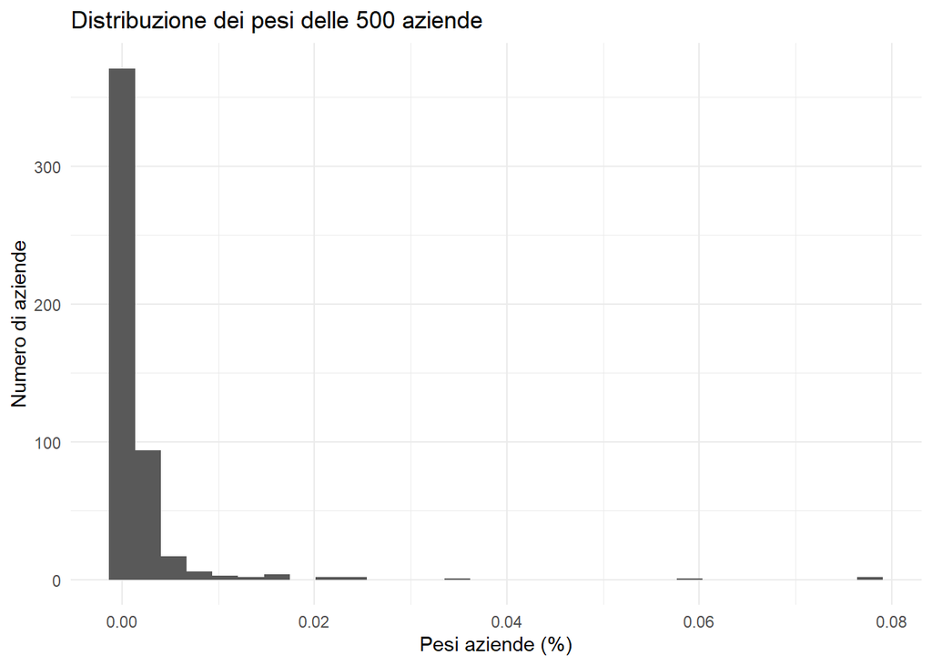

```r
distribuzione <-ggplot(sp500, aes(x = weight)) +
  geom_histogram( ) +
  labs(
    title = "Distribuzione dei pesi delle 500 aziende",
    x = "Pesi aziende (%)",
    y = "Numero di aziende"
  ) +
  theme_minimal()

distribuzione
```

L’istogramma mostra che i pesi delle aziende sono distribuiti in modo asimmetrico: la maggior parte delle aziende ha un peso molto basso, mentre solo poche aziende hanno pesi elevati. Questo indica che il contributo delle aziende all’indice non è uniforme e che alcune società hanno un’influenza molto maggiore rispetto alle altre.

# SECONDA DOMANDA

How much of the index is represented by its largest companies?

```r
#peso totale di tutte le aziende
tot_weight = sum(sp500$weight)

#peso delle prime 10 aziende
top_10 <- sp500 |>
  arrange(desc(weight)) |>
  head(10)

top_weight <- sum(top_10$weight)

#percentuale
percentuale <- (top_weight / tot_weight) * 100
percentuale <- round(percentuale, 2)
cat ("La percentuale delle prime 10 aziende con peso maggiore ricopre il:", percentuale, "% dell'intero peso delle aziende")
```

```
## La percentuale delle prime 10 aziende con peso maggiore ricopre il: 37.36 % dell'intero peso delle aziende
```

# TERZA DOMANDA

What does the Lorenz curve tell us about concentration?

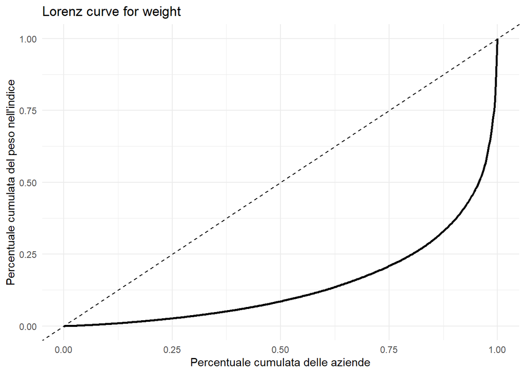

```r
#curva di lorenz
lorenz <- Lc(sp500$weight)

df_lorenz <- data.frame(p = lorenz$p, L = lorenz$L)

ggplot(df_lorenz, aes(p, L)) +
  geom_line(linewidth = 1) +
  geom_abline(slope=1, intercept = 0, linetype = "dashed") +
  labs(
    title = "Lorenz curve for weight",
    x = "Percentuale cumulata delle aziende",
    y = "Percentuale cumulata del peso nell'indice"
  ) +
  theme_minimal()
```

# QUARTA DOMANDA

What is the Gini coefficient of the S&P 500 weights?

Il coefficiente di Gini è una misura statistica che serve a quantificare la disuguaglianza (o la concentrazione) all’interno di una distribuzione di valori.

- Valore 0 significa che tutte le componenti hanno esattamente lo stesso peso
- Valore 1 significa che l’intero peso dell’indice è concentrato in un’unica azienda

```r
gini_weight = Gini(sp500$weight)
gini_weight
```

```
## [1] 0.7116953
```

Il valore di Gini conferma ciò che si può vedere con la curva di Lorenz